# cv_ivar

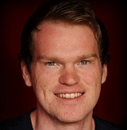

### Key Skills

- Excellent academic performance in analytical subjects (coding, math, statistics, etc.)
- Fast learner (example: learned fluent Portuguese in < 6 months)
- High working capacity (example: MSc at NTNU was completed during full time job as engineer)

### Technical skills

**Languages:** Python, JavaScript, R  
**Databases:** SQL (MySQL, PostgreSQL)  
**Frameworks:** FastAPI, Dash(Plotly)  
**Other skills:** AWS, Azure (cloud computing), Docker (containers), Git (source control)

### Languages

**Norwegian:** Native  
**English:** Speak and write fluently  
**Portuguese:** Speak and write fluently

### Hobbies

Language learning  
Travel  
Coding

# Ivar Soares Urdalen

Looking for roles in the Data Science / Finance space

Hi! I am on a path to make a career change from Civil Engineering to Data Science. I am currently pursuing a [MSc in Financial Engineering](https://www.wqu.edu/programs/mscfe/) from [World Quant University](https://www.wqu.edu/) while also taking courses/certifications and developing my own coding projects in data science. Check out my [website](https://ivarurdalen.github.io) to learn more about me and connect.

## Work

[output not shown]

## Personal Projects

| Current \| 2022 | **[Stock Analysis Dashboard](https://github.com/ivarurdalen/stockanalysis)** Technology: Python, Plotly/Dash, SQlite Created a dashboard for statistical and technical analysis of stocks. |
| --- | --- |

## Education

[output not shown]

## Awards

[output not shown]

## Courses

[output not shown]

This data driven CV is made with [Quarto](https://quarto.org/) and Google Sheets. Last updated on nov 29, 2022.  
Code available on [GitHub](https://github.com/ivarurdalen/).